# Tarifa Zero no Brasil:

a gratuidade no transporte público em municípios brasileiros

Aline Maria e João Lucas

2024

# Tarifa Zero no Brasil

O Brasil enfrenta sérios problemas de mobilidade urbana, incluindo congestionamentos intensos, poluição atmosférica e um incentivo predominante ao uso de veículos individuais. Além disso, o transporte público é frequentemente caro e inacessível para muitos cidadãos. A Tarifa Zero é apresentada como uma solução viável para esses desafios, oferecendo transporte gratuito e promovendo uma alternativa ecológica e acessível. Essa política pode ajudar a reduzir o tráfego, diminuir a poluição e tornar o transporte público uma opção mais atraente e inclusiva para todos.

[figure not shown]

# Objetivos

O objetivo principal é mapear a adoção da Tarifa Zero nos transportes públicos das cidades brasileiras. Além disso, a pesquisa analisará a relação entre a Competição Política e o PIB per capita com a adoção dessa política, em uma tentativa de identificar fatores decisivos no processo de sua implementação. As hipóteses testadas são:

- Municípios com alta competitividade política têm maior chance de adotar a Tarifa Zero para que os prefeitos se destaquem nas eleições.
- Municípios com alto PIB per capita são mais propensos a adotar a Tarifa Zero, como um indicador de desenvolvimento econômico.

# Contexto

Nos últimos anos, especialmente a partir de 2020, a adoção dessa política cresceu significativamente, com mais de 110 dos municípios brasileiros implementando a gratuidade universal. Essa pauta tem ganhado destaque nacional, refletindo sua importância social e política, além de responder à crise de financiamento do transporte público exacerbada pela pandemia. É crucial analisar a evolução e os fatores que influenciam essa implementação, como a competição política e o PIB per capita.

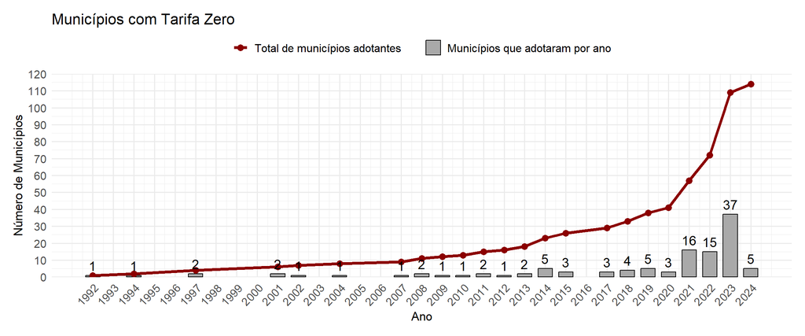

—

# Método

Para a realização desse trabalho, foram utilizados os dados compilados por Daniel Santini (2024), referentes aos municípios que adotam a Tarifa Zero universal no Brasil, bem como suas respectivas UFs e porte populacional. Além disso, utilizamos dados provenientes de fontes oficiais como IBGE e TSE, relativos ao PIB per capita e à competição eleitoral (calculada a partir do número efetivo de partidos e dos resultados eleitorais). Fizemos uma análise estatística descritiva com o objetivo de estabelecer um panorama dos municípios que adotaram a gratuidade universal no transporte público, identificando o porte populacional e, também, a sua distribuição geográfica pelo país. Também analisamos se o PIB per capita e a competição eleitoral são relevantes no processo de adoção dessa política, a partir de uma amostra dos municípios com uma população entre 20 mil e 100 mil habitantes (totalizando 1370 municípios). —

# Municípios por porte populacional

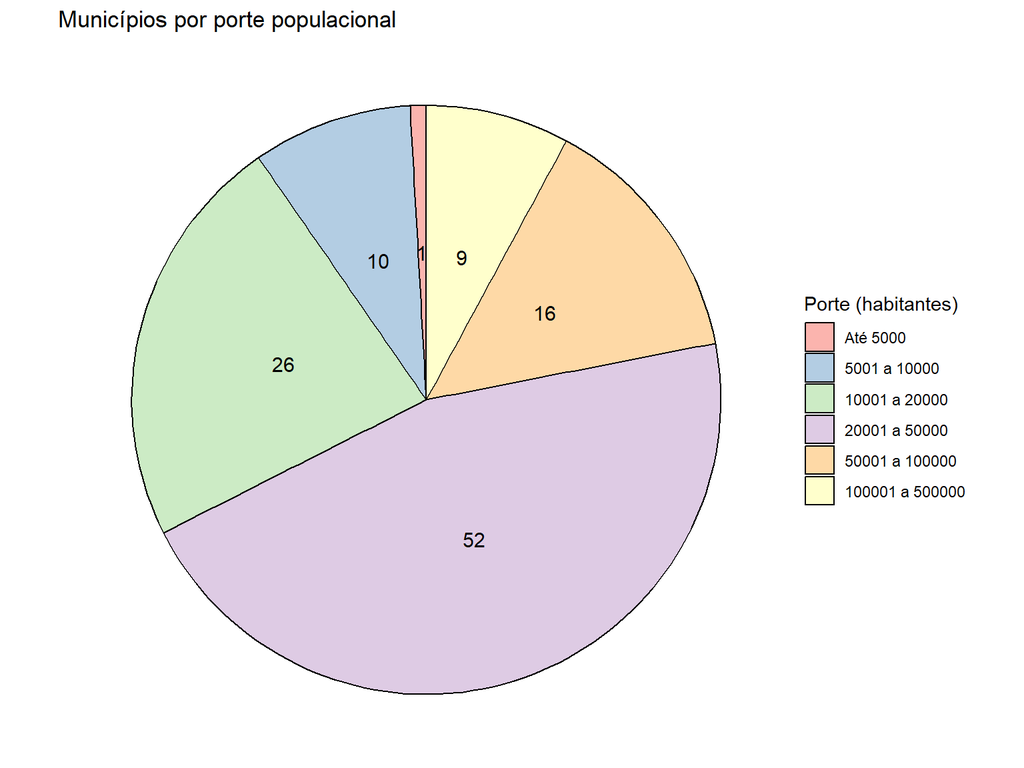

# Distribuição Geográfica

| Estado | Sigla | Número de Municípios Adotantes |
| --- | --- | --- |
| São Paulo | SP | 37 |
| Minas Gerais | MG | 27 |
| Paraná | PR | 14 |
| Rio de Janeiro | RJ | 13 |
| Santa Catarina | SC | 7 |
| Goiás | GO | 5 |
| Rio Grande do Sul | RS | 4 |
| Ceará | CE | 3 |
| Bahia | BA | 1 |
| Espírito Santo | ES | 1 |
| Mato Grosso do Sul | MS | 1 |
| Rondônia | RO | 1 |

# Relevância das variáveis: competição política e PIB per capita

```
## Analysis of Deviance Table (Type II tests)
##
## Response: adotatz
##                    Df  Chisq Pr(>Chisq)
## CompetiçãoPolítica  1 0.2627   0.608239
## PIBpercapitaMedia   1 6.9388   0.008435 **
## ---
## Signif. codes:  0 '***' 0.001 '**' 0.01 '*' 0.05 '.' 0.1 ' ' 1
```

- CompetiçãoPolítica: Não parece ter um efeito significativo na adoção da Tarifa Zero.
- PIBpercapitaMedia: Tem um efeito significativo na adoção da Tarifa Zero (p = 0.00843). O coeficiente negativo sugere que, à medida que o PIB per capita médio aumenta, a probabilidade de adoção da Tarifa Zero diminui. Ou seja, municípios com PIB per capita mais alto são menos propensos a adotar a Tarifa Zero.

# Razões de chance

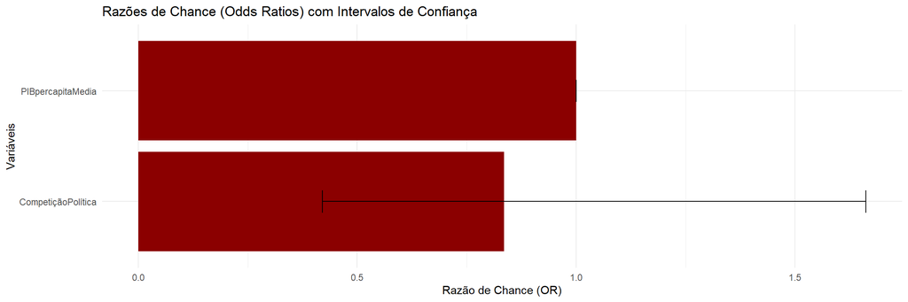

# Conclusão

- É notório o aumento no número de adoções da Tarifa Zero no Brasil, especialmente após a pandemia de 2020.
- Dos 114 municípios adotantes, 52 têm o porte populacional entre 20 e 50 mil habitantes.
- São Paulo é o estado com mais municípios adotantes, seguido por Minas Gerais e Paraná. Destaque para a região sudeste como região com mais municípios adotantes.
- O modelo de regressão logística binária mostrou que a competição política não é uma previsora para a adoção da Tarifa Zero, mas que o PIB per capita pode ser. Na amostra em questão, ainda que o efeito seja consideravelmente pequeno, quanto maior o PIB per capita do município, menor a chance da implementação dessa política, se contrapondo a nossa hipótese de que quanto maior a renda, maior a chance. O PIB per capita é estatisticamente significativo, mas o impacto real é muito pequeno. Isso significa que, embora o PIB per capita influencie a adoção da Tarifa Zero de maneira mensurável, a magnitude do efeito é tão pequena que pode não ter um impacto significativo na prática.